# Index

Laura_Hakkinen

2024-06-24

# YONI fungal ITS2: making phyloseq object, calculating diversities and annotating FUNGuild

```r
library('phyloseq')
library("cowplot")
library("dplyr")
library("ggplot2")
library("vegan")
library("microbiome")
library("tibble")
library("readxl")
library(tidyverse)
```

# 1. import OTUs and taxa

```r
setwd('\\\\ad.helsinki.fi\\home\\l\\lehakkin\\Desktop\\YONI_ITS_analyses\\R_ITS_yoni\\Analyses_final\\RE_ANNOTATION_2024')

otu <- read.table("ITS_OTUs_mod.txt", sep="\t", header=FALSE)
tax <- read.table("ITS_OTUs.UNITEv10_sh_99.wang.taxonomy", sep="\t", header=FALSE)
```

```r
dif <- setdiff(tax$V1, otu$V1)
dif
```

```
## [1] "OTU57653" "OTU58305"
```

These OTUs are missing from OTU table but are present in tax table? Let’s remove them form tax table Also, lets tweek the table row names and columns

```r
# modify otu table

colnames(otu)=otu[c(1),]
# erase the first row, as now it is doubled
otu=otu[-c(1),]

# make first column into rownames
rownames(otu) <- otu$`OTU ID`
otu <- otu[, -c(1)]
```

```r
# let's make a copy of tax table
tax.orig <- tax

# change column names
colnames(tax)[1] <- "OTU"
colnames(tax)[2] <- "taxa"

# and modify the tax, where in the str_remove_all . means any single character
tax <- tax %>%
  mutate(taxa = str_remove_all(taxa, ".__")) %>%
  separate(taxa,
           into = c("kingdom", "phylum", "class", "order", "family", "genus", "species"),
           sep = ";")
```

```
## Warning: Expected 7 pieces. Additional pieces discarded in 70200 rows [1, 2, 3, 4, 5, 6,
## 7, 8, 9, 10, 11, 12, 13, 14, 15, 16, 17, 18, 19, 20, ...].
```

Everything went well but I got a warning message, because there are an extra ; at the end of the line so the last column is not made. which is correct. Let’s check if we now have NAs, just to check everything is ok.

```r
sum(is.na(tax$OTU))
```

```
## [1] 0
```

```r
sum(is.na(tax$kingdom))
```

```
## [1] 0
```

```r
sum(is.na(tax$phylum))
```

```
## [1] 0
```

```r
sum(is.na(tax$class))
```

```
## [1] 0
```

```r
sum(is.na(tax$order))
```

```
## [1] 0
```

```r
sum(is.na(tax$family))
```

```
## [1] 0
```

```r
sum(is.na(tax$genus))
```

```
## [1] 0
```

```r
sum(is.na(tax$species))
```

```
## [1] 0
```

Let’s remove the parantheses and numbers

```r
tax$kingdom <- sub("\\(.*", "", tax$kingdom)
tax$phylum <- sub("\\(.*", "", tax$phylum)
tax$class <- sub("\\(.*", "", tax$class)
tax$order <- sub("\\(.*", "", tax$order)
tax$family <- sub("\\(.*", "", tax$family)
tax$genus <- sub("\\(.*", "", tax$genus)
tax$species <- sub("\\(.*", "", tax$species)
```

Check unique values of the higher taxons

```r
unique(tax$kingdom)
```

```
## [1] "Fungi"
```

```r
unique(tax$phylum)
```

```
##  [1] "Ascomycota"            "Basidiomycota"         "Fungi_unclassified"
##  [4] "Rozellomycota"         "Basidiobolomycota"     "Chytridiomycota"
##  [7] "Mortierellomycota"     "unclassified"          "Glomeromycota"
## [10] "Mucoromycota"          "Zoopagomycota"         "Monoblepharomycota"
## [13] "Olpidiomycota"         "Kickxellomycota"       "Entorrhizomycota"
## [16] "Aphelidiomycota"       "Neocallimastigomycota"
```

## 1.2. remove the extra OTUs in tax table

“OTU57653” “OTU58305”

```r
tax <- subset(tax, OTU!="OTU57653")
tax <- subset(tax, OTU!="OTU58305")
```

# 2. import meta data

```r
samples <- read.csv2('\\\\ad.helsinki.fi\\home\\l\\lehakkin\\Desktop\\YONI_ITS_analyses\\R_ITS_yoni\\Analyses_final\\RE_ANNOTATION_2024\\sample_data_updated_root_biomass.csv')
# change some column names
colnames(samples)[which(names(samples) == "production_type")] <- "sample_type"
```

## 2.1. change otu table sample names

```r
x <- otu

x <- t(x)
x <- as.data.frame(x)
x <- rownames_to_column(x)

y <- samples[, c(1,2)]
x <- left_join(y, x, by = c("ID"="rowname"))
x <- x[, -c(1)]
rownames(x) <- x$sampleID
x <- x[, -c(1)]
x <- t(x)
otu <- x
rm(x)
rm(y)
library(dplyr)
otu <- as.data.frame(otu)
otu <- otu %>% mutate_if(is.character, as.numeric)
```

# 3. make phyloseq object

```r
rownames(tax) <- tax$OTU
tax <- tax[, -c(1)]
rownames(samples) <- samples$sampleID
samples <- samples[, -c(1)]
samples <- sample_data(samples)
otu <- as.matrix(otu)
otu <- otu_table(otu, taxa_are_rows = TRUE)
tax <- tax_table(as.matrix(tax))

ps <- phyloseq(otu, tax, samples)
ps
```

```
## phyloseq-class experiment-level object
## otu_table()   OTU Table:         [ 70198 taxa and 142 samples ]
## sample_data() Sample Data:       [ 142 samples by 22 sample variables ]
## tax_table()   Taxonomy Table:    [ 70198 taxa by 7 taxonomic ranks ]
```

# remove unclassified phyla and controls

Fungi_unclassified unclassified

```r
ps <- subset_samples(ps, sampleID != "0ctrl-1")
ps <- subset_samples(ps, sampleID != "0ctrl-2")
ps
```

```
## phyloseq-class experiment-level object
## otu_table()   OTU Table:         [ 70198 taxa and 140 samples ]
## sample_data() Sample Data:       [ 140 samples by 22 sample variables ]
## tax_table()   Taxonomy Table:    [ 70198 taxa by 7 taxonomic ranks ]
```

```r
# You have only submitted samples, not OTUs. Define prevalence of each taxa
# (in how many samples did each taxa appear at least once)
prev0 = apply(X = otu_table(ps),
              MARGIN = ifelse(taxa_are_rows(ps), yes = 1, no = 2),
              FUN = function(x){sum(x > 0)})

# Execute prevalence filter, using `prune_taxa()` function
ps = prune_taxa((prev0 > 0), ps)
ps
```

```
## phyloseq-class experiment-level object
## otu_table()   OTU Table:         [ 70198 taxa and 140 samples ]
## sample_data() Sample Data:       [ 140 samples by 22 sample variables ]
## tax_table()   Taxonomy Table:    [ 70198 taxa by 7 taxonomic ranks ]
```

```r
rm(prev0)
rm(tax.orig)

#I will remove two: "Fungi_unclassified" and "unclassified"
ps <- subset_taxa(ps, phylum != "Fungi_unclassified" & phylum != "unclassified")
ps
```

```
## phyloseq-class experiment-level object
## otu_table()   OTU Table:         [ 68186 taxa and 140 samples ]
## sample_data() Sample Data:       [ 140 samples by 22 sample variables ]
## tax_table()   Taxonomy Table:    [ 68186 taxa by 7 taxonomic ranks ]
```

# 4. save phyloseq with sng

```r
ps_sng <- ps
setwd('\\\\ad.helsinki.fi\\home\\l\\lehakkin\\Desktop\\YONI_ITS_analyses\\R_ITS_yoni\\Analyses_final\\RE_ANNOTATION_2024\\PROJECT_YONI_fungal_ITS')
save(ps_sng, file='ps_phyloseq_with_sng')
```

# 5. Remove sngs and save

```r
ps <- filter_taxa(ps, function (x) {sum(x > 0) > 1}, prune=TRUE)

setwd('\\\\ad.helsinki.fi\\home\\l\\lehakkin\\Desktop\\YONI_ITS_analyses\\R_ITS_yoni\\Analyses_final\\RE_ANNOTATION_2024\\PROJECT_YONI_fungal_ITS')
save(ps, file='ps_FINAL')

ps
```

```
## phyloseq-class experiment-level object
## otu_table()   OTU Table:         [ 20610 taxa and 140 samples ]
## sample_data() Sample Data:       [ 140 samples by 22 sample variables ]
## tax_table()   Taxonomy Table:    [ 20610 taxa by 7 taxonomic ranks ]
```

```r
summarize_phyloseq(ps)
```

```
## Compositional = NO2
```

[output not shown]

```
## [[1]]
## [1] "1] Min. number of reads = 44"
##
## [[2]]
## [1] "2] Max. number of reads = 410851"
##
## [[3]]
## [1] "3] Total number of reads = 11539503"
##
## [[4]]
## [1] "4] Average number of reads = 82425.0214285714"
##
## [[5]]
## [1] "5] Median number of reads = 79653.5"
##
## [[6]]
## [1] "7] Sparsity = 0.928178415470992"
##
## [[7]]
## [1] "6] Any OTU sum to 1 or less? NO"
##
## [[8]]
## [1] "8] Number of singletons = 0"
##
## [[9]]
## [1] "9] Percent of OTUs that are singletons \n        (i.e. exactly one read detected across all samples)0"
##
## [[10]]
## [1] "10] Number of sample variables are: 22"
##
## [[11]]
##  [1] "sampleID"            "plot"                "sampling_position"
##  [4] "actual_sample_depth" "depth"               "depth_numerical"
##  [7] "vegetation"          "sample_type"         "root_mgg"
## [10] "pH_H2O"              "EC_uScm"             "C_g_per_kg"
## [13] "N_gkg"               "TP_gkg"              "Alox_mmolkg"
## [16] "Feox_mmolkg"         "oxides_mmolkg"       "PH2O_mgkg"
## [19] "Porg_mgkg"           "DOC_mgkg"            "Pinorg_mgkg"
## [22] "C_per_N"
```

# 6. Check low readcounts

```r
readcount(ps)
```

```
##   CG9.1_0to10  CG9.1_10to20  CG9.1_20to30  CG9.1_30to40  CG9.1_40to70
##         86263         86079        104971         70687            44
##   CG9.2_0to10  CG9.2_10to20  CG9.2_20to30  CG9.2_30to40  CG9.2_40to80
##         93325         99797         71502         33354         12765
##   CG9.3_0to10  CG9.3_10to20  CG9.3_20to30  CG9.3_30to40  CG9.3_40to70
##         80231         84314         95845        119875          8588
##  CPO5.1_0to10 CPO5.1_10to20 CPO5.1_20to30 CPO5.1_30to40 CPO5.1_40to70
##         98378         70183         84869        104719         18979
##  CPO5.2_0to10 CPO5.2_10to20 CPO5.2_20to30 CPO5.2_30to40 CPO5.2_40to70
##         71870         95165         58356         13410          7818
##  CPO5.3_0to10 CPO5.3_10to20 CPO5.3_20to30 CPO5.3_30to40 CPO5.3_40to80
##         77865         69685         69812        100730         29285
##  CR14.1_0to10 CR14.1_10to20 CR14.1_20to30 CR14.1_30to40 CR14.1_40to80
##         87835         83770         45199        191427         10410
##  CR14.2_0to10 CR14.2_10to20 CR14.2_20to30 CR14.2_30to40 CR14.2_40to70
##         79191         80650        168434        108506         35667
##  CR14.3_0to10 CR14.3_10to20 CR14.3_20to30 CR14.3_30to40 CR14.3_40to60
##         85581         66271         90307        206728         27639
##      M1_0to10     M1_10to20     M1_20to30     M1_30to40     M1_40to60
##         20487         79126         80116         65933          9920
##      M2_0to10     M2_10to20     M2_20to30     M2_30to40     M2_40to60
##        104802         92361         68349         48693         13643
##      M3_0to10     M3_10to20     M3_20to30     M3_30to40     M3_40to60
##         89502         88371         96903         49946         65688
##   NG2A1_0to10  NG2A1_10to20  NG2A1_20to30  NG2A1_30to40  NG2A1_40to70
##         63024        150089        215010        410851         21745
##   NG2A2_0to10  NG2A2_10to20  NG2A2_20to30  NG2A2_30to40  NG2A2_40to70
##        122936        138014        150337        232098         28984
##   NG2A3_0to10  NG2A3_10to20  NG2A3_20to30  NG2A3_30to40  NG2A3_40to70
##         70345        112821        151484         56781         48499
##   NG2B1_0to10  NG2B1_10to20  NG2B1_20to30  NG2B1_30to40  NG2B1_40to70
##         71098        133953        156486         56105         45557
##   NG2B2_0to10  NG2B2_10to20  NG2B2_20to30  NG2B2_30to40  NG2B2_40to70
##         65605        203928        161140         71344           811
##   NG2B3_0to10  NG2B3_10to20  NG2B3_20to30  NG2B3_30to40  NG2B3_40to70
##         91494        103358        122182           526         18249
##   NG3.2_0to10  NG3.2_10to20  NG3.2_20to30  NG3.2_30to40  NG3.2_40to70
##         30720        126078         74239        153319         28542
##   NG3.3_0to10  NG3.3_10to20  NG3.3_20to30  NG3.3_30to40  NG3.3_40to60
##         15342         69130         56845        119149         72310
##  OG10.1_0to10 OG10.1_10to20 OG10.1_20to30 OG10.1_30to40 OG10.1_40to80
##         65025         73499         63754         23026          9882
##  OG10.2_0to10 OG10.2_10to20 OG10.2_20to30 OG10.2_30to40 OG10.2_40to70
##        107655         77838         90829         97084         32336
##  OG10.3_0to10 OG10.3_10to20 OG10.3_20to30 OG10.3_30to40 OG10.3_40to70
##         75755         80589         99232         67396         27950
##  OPO6.2_0to10 OPO6.2_10to20 OPO6.2_20to30 OPO6.2_30to40 OPO6.2_40to70
##         98465         84444         63563        103414         86941
##  OPO6.3_0to10 OPO6.3_10to20 OPO6.3_20to30 OPO6.3_30to40 OPO6.3_40to70
##        103969         85383         66316        166823         61540
##  OR13.1_0to10 OR13.1_10to20 OR13.1_20to30 OR13.1_30to40 OR13.1_40to80
##         94567        107459        112756         92093         20227
##  OR13.2_0to10 OR13.2_10to20 OR13.2_20to30 OR13.2_30to40 OR13.2_40to60
##        113845         22672         29060         12432         15481
##  OR13.3_0to10 OR13.3_10to20 OR13.3_20to30 OR13.3_30to40 OR13.3_40to60
##        101629         99800         91229         97335        235463
```

# 7. IMPORTANT! Bug in the TAX table!!

I noticed that there is a mistake in the taxonomy, so that sometimes I have “unclassified” annotation at lets say genus level, although I have annotation at lets say family level

In these cases I rather have at the genus level the annotation “family_unclassified”

```r
tax <- as.data.frame(tax_table(ps))
```

I have no unclassified at phylum level

change first at level:

class

```r
tax[tax$class == "unclassified", "phylum"]
```

```
##   [1] "Chytridiomycota"    "Basidiomycota"      "Chytridiomycota"
##   [4] "Monoblepharomycota" "Rozellomycota"      "Basidiomycota"
##   [7] "Chytridiomycota"    "Rozellomycota"      "Chytridiomycota"
##  [10] "Rozellomycota"      "Rozellomycota"      "Chytridiomycota"
##  [13] "Rozellomycota"      "Rozellomycota"      "Chytridiomycota"
##  [16] "Rozellomycota"      "Rozellomycota"      "Rozellomycota"
##  [19] "Rozellomycota"      "Rozellomycota"      "Rozellomycota"
##  [22] "Rozellomycota"      "Rozellomycota"      "Rozellomycota"
##  [25] "Rozellomycota"      "Rozellomycota"      "Rozellomycota"
##  [28] "Basidiomycota"      "Basidiomycota"      "Basidiomycota"
##  [31] "Rozellomycota"      "Rozellomycota"      "Basidiomycota"
##  [34] "Basidiomycota"      "Kickxellomycota"    "Rozellomycota"
##  [37] "Basidiomycota"      "Basidiomycota"      "Rozellomycota"
##  [40] "Basidiomycota"      "Basidiomycota"      "Rozellomycota"
##  [43] "Chytridiomycota"    "Rozellomycota"      "Rozellomycota"
```

[output cut: 26 more lines]

```r
tax$class <- ifelse(tax$class == "unclassified", paste(tax$phylum, sep = "_", "unclassified"), as.character(tax$class))
```

And same for all rest ranks, but I have to replace the “_unclassified_unclassified” with “_unclassified” afterwards

order

```r
tax$order <- ifelse(tax$order == "unclassified", paste(tax$class, sep = "_", "unclassified"), as.character(tax$order))
```

```r
tax[] <- lapply(tax, gsub, pattern = "unclassified_unclassified", replacement = "unclassified", fixed = TRUE)
```

family

```r
tax$family <- ifelse(tax$family == "unclassified", paste(tax$order, sep = "_", "unclassified"), as.character(tax$family))
```

```r
tax[] <- lapply(tax, gsub, pattern = "unclassified_unclassified", replacement = "unclassified", fixed = TRUE)
```

genus

```r
tax$genus <- ifelse(tax$genus == "unclassified", paste(tax$family, sep = "_", "unclassified"), as.character(tax$genus))
```

```r
tax[] <- lapply(tax, gsub, pattern = "unclassified_unclassified", replacement = "unclassified", fixed = TRUE)
```

species

```r
tax$species <- ifelse(tax$species == "unclassified", paste(tax$genus, sep = "_", "unclassified"), as.character(tax$species))
```

```r
tax[] <- lapply(tax, gsub, pattern = "unclassified_unclassified", replacement = "unclassified", fixed = TRUE)
```

# 8. Save

Save the new modified ps as the “final version”

```r
setwd('\\\\ad.helsinki.fi\\home\\l\\lehakkin\\Desktop\\YONI_ITS_analyses\\R_ITS_yoni\\Analyses_final\\RE_ANNOTATION_2024\\PROJECT_YONI_fungal_ITS')

tax_table(ps) <- tax_table(as.matrix(tax))

save(ps, file='ps_FINAL')

ps
```

```
## phyloseq-class experiment-level object
## otu_table()   OTU Table:         [ 20610 taxa and 140 samples ]
## sample_data() Sample Data:       [ 140 samples by 22 sample variables ]
## tax_table()   Taxonomy Table:    [ 20610 taxa by 7 taxonomic ranks ]
```

```r
library("ggpubr")
```

```r
library('phyloseq')
library("cowplot")
library("dplyr")
library("ggplot2")
library("vegan")
library("microbiome")
library("tibble")
library(stringr)
library(reshape2)
library(tidyr)

setwd('\\\\ad.helsinki.fi\\home\\l\\lehakkin\\Desktop\\YONI_ITS_analyses\\R_ITS_yoni\\Analyses_final\\RE_ANNOTATION_2024\\PROJECT_YONI_fungal_ITS')

load('ps_FINAL')
ps
```

```
## phyloseq-class experiment-level object
## otu_table()   OTU Table:         [ 20610 taxa and 140 samples ]
## sample_data() Sample Data:       [ 140 samples by 22 sample variables ]
## tax_table()   Taxonomy Table:    [ 20610 taxa by 7 taxonomic ranks ]
```

```r
meta <- meta(ps)
```

# 1. Change metadata numerics

```r
# Column indices to be converted numeric
i <- c(6, 9:22)
meta[, i] <- apply(meta[, i], 2, function(x) as.numeric(as.character(x)))

meta$depth_numerical[meta$depth_numerical == 0] <- 5
meta$depth_numerical[meta$depth_numerical == 10] <- 15
meta$depth_numerical[meta$depth_numerical == 20] <- 25
meta$depth_numerical[meta$depth_numerical == 30] <- 35
meta$depth_numerical[meta$depth_numerical == 40] <- 60

# change natural_grass to meadow
 meta <- data.frame(lapply(meta, function(x) {gsub("Natural_grass", "meadow", x)}))
 rownames(meta) <- meta$sampleID

sample_data(ps) <- sample_data(meta)

setwd('\\\\ad.helsinki.fi\\home\\l\\lehakkin\\Desktop\\YONI_ITS_analyses\\R_ITS_yoni\\Analyses_final\\RE_ANNOTATION_2024\\PROJECT_YONI_fungal_ITS')
save(ps, file='ps_FINAL')
```

# 2. Calculate diversities

## 2.1. First without singletons

```r
div <- microbiome::alpha(ps, index = "all")
```

```
## Observed richness
```

```
## Other forms of richness
```

```
## Diversity
```

```
## Evenness
```

```
## Dominance
```

```
## Rarity
```

```r
# Assign the estimated diversity to sample metadata
sample_data(ps)$observed <- div$observed
sample_data(ps)$chao1 <- div$chao1
sample_data(ps)$shannon <- div$diversity_shannon

meta <- meta(ps)

meta$sample_type <- as.factor(meta$sample_type)

meta$sample_type <- factor(meta$sample_type, levels = c("forest", "meadow", "organic", "conventional"))

# Column indices to be converted numeric
i <- c(6, 9:25)
meta[, i] <- apply(meta[, i], 2, function(x) as.numeric(as.character(x)))

sample_data(ps) <- sample_data(meta)

setwd('\\\\ad.helsinki.fi\\home\\l\\lehakkin\\Desktop\\YONI_ITS_analyses\\R_ITS_yoni\\Analyses_final\\RE_ANNOTATION_2024\\PROJECT_YONI_fungal_ITS')
save(ps, file='ps_FINAL')
ps
```

```
## phyloseq-class experiment-level object
## otu_table()   OTU Table:         [ 20610 taxa and 140 samples ]
## sample_data() Sample Data:       [ 140 samples by 25 sample variables ]
## tax_table()   Taxonomy Table:    [ 20610 taxa by 7 taxonomic ranks ]
```

## 2.2 with singletons

I will use the one without singletons, but just for comparison, I also calculate with singletons

```r
setwd('\\\\ad.helsinki.fi\\home\\l\\lehakkin\\Desktop\\YONI_ITS_analyses\\R_ITS_yoni\\Analyses_final\\RE_ANNOTATION_2024\\PROJECT_YONI_fungal_ITS')
load('ps_phyloseq_with_sng')

div <- microbiome::alpha(ps_sng, index = "all")
```

```
## Observed richness
```

```
## Other forms of richness
```

```
## Diversity
```

```
## Evenness
```

```
## Dominance
```

```
## Rarity
```

```r
# Assign the estimated diversity to sample metadata
sample_data(ps)$observed_sng <- div$observed
sample_data(ps)$chao1_sng <- div$chao1
sample_data(ps)$shannon_sng <- div$diversity_shannon

meta <- meta(ps)

save(ps, file='ps_FINAL')
```

# 3. plot diversity

## color palette

```r
# create your own color palette for sample types
MyPalette <- c(forest = "#1167b1", meadow = "#fbc02d", organic = "#8a8a8a", conventional =  "#b71c1c")
```

## plot depthwise

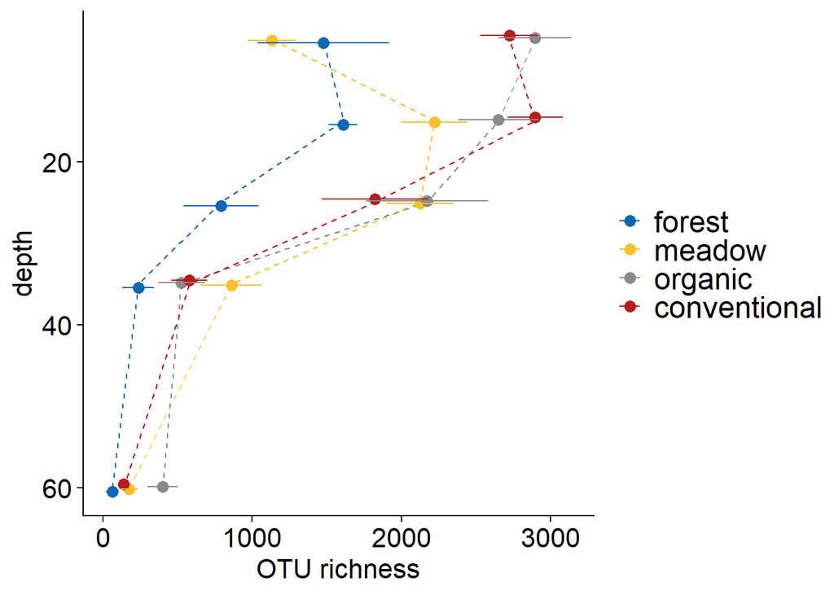

```r
# OTU richness
OTU_rich <- meta %>%
  dplyr::group_by(sample_type, depth_numerical) %>%
  dplyr::summarise(mean = mean(observed, na.rm = TRUE), se = (sd(observed, na.rm = TRUE)/sqrt(length((observed))))) %>%
  dplyr::ungroup() %>%
  ggplot(aes(y=mean, depth_numerical, color=sample_type)) +
  geom_line(linetype = "dashed") +
  geom_point(size=3, position=position_dodge(1.2)) +
  geom_errorbar(aes(ymin=mean-se, ymax=mean+se), width=.5, position=position_dodge(1.2)) + coord_flip() + scale_x_reverse() + theme(plot.title = element_text(size = 20, hjust = 0.5)) + theme(panel.border = element_rect(colour = "black", fill=NA, size=0.5)) + theme_cowplot() +
  theme(axis.text = element_text(size=16),
        axis.title = element_text(size=16),
        legend.text = element_text(size=18),
        legend.title = element_text(size=16),
        title = element_text(size=18)) +
  scale_y_continuous(name="OTU richness") +
  labs(x = "depth") + theme(legend.title = element_blank()) + scale_colour_manual(values = MyPalette)
OTU_rich
```

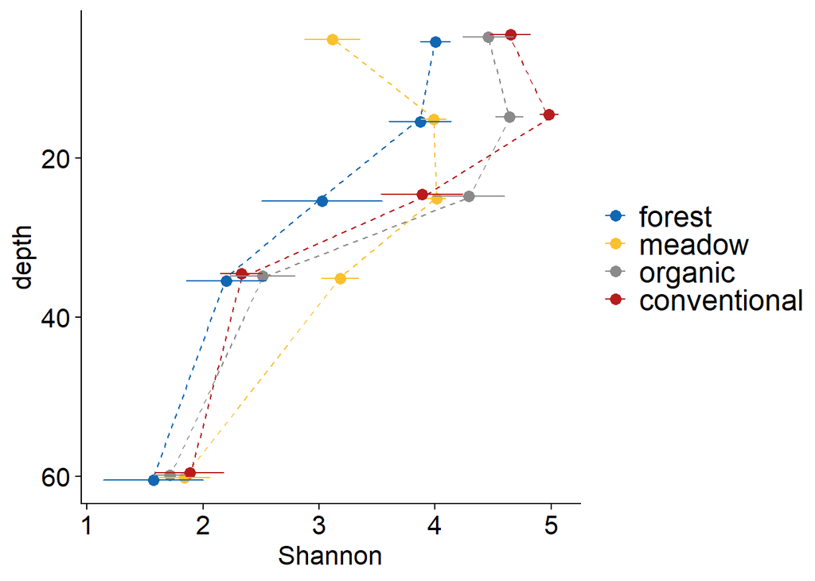

```r
# shannon
shannon <- meta %>%
  dplyr::group_by(sample_type, depth_numerical) %>%
  dplyr::summarise(mean = mean(shannon, na.rm = TRUE), se = (sd(shannon, na.rm = TRUE)/sqrt(length((shannon))))) %>%
  dplyr::ungroup() %>%
  ggplot(aes(y=mean, depth_numerical, color=sample_type)) +
  geom_line(linetype = "dashed") +
  geom_point(size=3, position=position_dodge(1.2)) +
  geom_errorbar(aes(ymin=mean-se, ymax=mean+se), width=.5, position=position_dodge(1.2)) + coord_flip() + scale_x_reverse() + theme(plot.title = element_text(size = 20, hjust = 0.5)) + theme(panel.border = element_rect(colour = "black", fill=NA, size=0.5)) + theme_cowplot() +
  theme(axis.text = element_text(size=16),
        axis.title = element_text(size=16),
        legend.text = element_text(size=18),
        legend.title = element_text(size=16),
        title = element_text(size=18)) +
  scale_y_continuous(name="Shannon") +
  labs(x = "depth") + theme(legend.title = element_blank()) + scale_colour_manual(values = MyPalette)
shannon
```

## 3.2. plot with sng

## plot depthwise

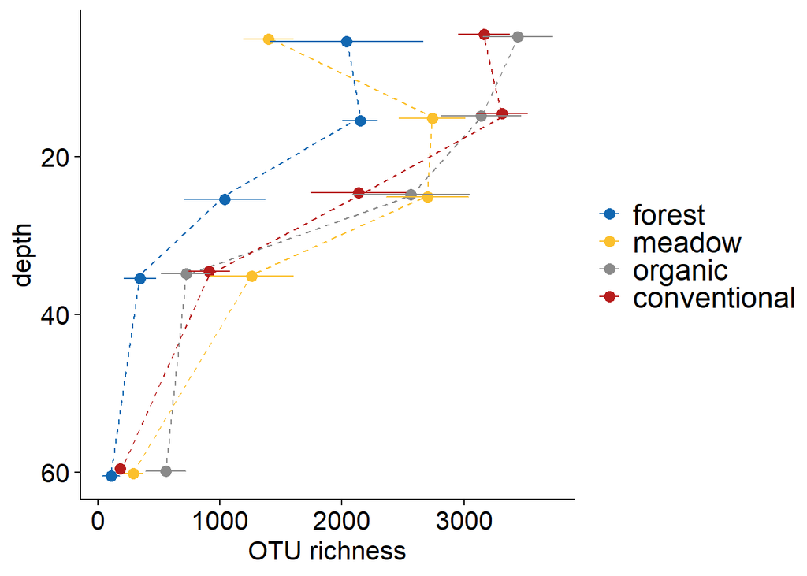

```r
# OTU richness
OTU_rich_sng <- meta %>%
  dplyr::group_by(sample_type, depth_numerical) %>%
  dplyr::summarise(mean = mean(observed_sng, na.rm = TRUE), se = (sd(observed_sng, na.rm = TRUE)/sqrt(length((observed_sng))))) %>%
  dplyr::ungroup() %>%
  ggplot(aes(y=mean, depth_numerical, color=sample_type)) +
  geom_line(linetype = "dashed") +
  geom_point(size=3, position=position_dodge(1.2)) +
  geom_errorbar(aes(ymin=mean-se, ymax=mean+se), width=.5, position=position_dodge(1.2)) + coord_flip() + scale_x_reverse() + theme(plot.title = element_text(size = 20, hjust = 0.5)) + theme(panel.border = element_rect(colour = "black", fill=NA, size=0.5)) + theme_cowplot() +
  theme(axis.text = element_text(size=16),
        axis.title = element_text(size=16),
        legend.text = element_text(size=18),
        legend.title = element_text(size=16),
        title = element_text(size=18)) +
  scale_y_continuous(name="OTU richness") +
  labs(x = "depth") + theme(legend.title = element_blank()) + scale_colour_manual(values = MyPalette)
OTU_rich_sng
```

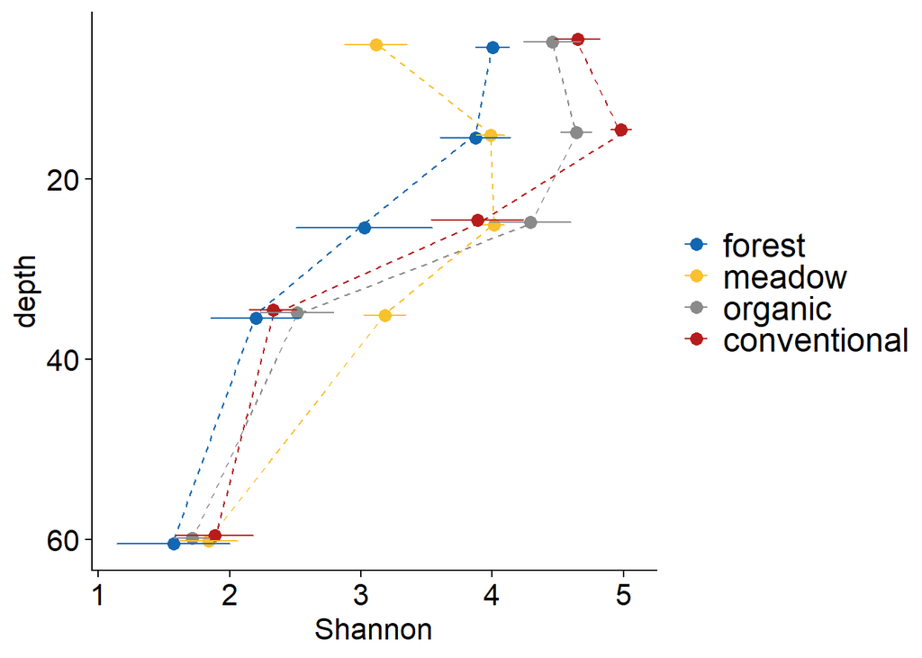

```r
# shannon
shannon_sng <- meta %>%
  dplyr::group_by(sample_type, depth_numerical) %>%
  dplyr::summarise(mean = mean(shannon_sng, na.rm = TRUE), se = (sd(shannon_sng, na.rm = TRUE)/sqrt(length((shannon_sng))))) %>%
  dplyr::ungroup() %>%
  ggplot(aes(y=mean, depth_numerical, color=sample_type)) +
  geom_line(linetype = "dashed") +
  geom_point(size=3, position=position_dodge(1.2)) +
  geom_errorbar(aes(ymin=mean-se, ymax=mean+se), width=.5, position=position_dodge(1.2)) + coord_flip() + scale_x_reverse() + theme(plot.title = element_text(size = 20, hjust = 0.5)) + theme(panel.border = element_rect(colour = "black", fill=NA, size=0.5)) + theme_cowplot() +
  theme(axis.text = element_text(size=16),
        axis.title = element_text(size=16),
        legend.text = element_text(size=18),
        legend.title = element_text(size=16),
        title = element_text(size=18)) +
  scale_y_continuous(name="Shannon") +
  labs(x = "depth") + theme(legend.title = element_blank()) + scale_colour_manual(values = MyPalette)
shannon
```

```r
library('phyloseq')
library("cowplot")
library("dplyr")
library("ggplot2")
library("vegan")
library("microbiome")
library("tibble")
library("RColorBrewer") # nice color options
library(multcompView)
library(rcompanion)
library(car)
library(multcomp)
library(stringr)
library(ggrepel)
library(MicEco)
library(metagMisc)
setwd('\\\\ad.helsinki.fi\\home\\l\\lehakkin\\Desktop\\YONI_ITS_analyses\\R_ITS_yoni\\Analyses_final\\RE_ANNOTATION_2024\\PROJECT_YONI_fungal_ITS')

load('ps_FINAL')
ps
```

```
## phyloseq-class experiment-level object
## otu_table()   OTU Table:         [ 20610 taxa and 140 samples ]
## sample_data() Sample Data:       [ 140 samples by 28 sample variables ]
## tax_table()   Taxonomy Table:    [ 20610 taxa by 7 taxonomic ranks ]
```

# 1. Load and save FUNGuild

```r
#FG <- parse_funguild()
#attr(FG, "DownloadDate")  # Check when the database was downloaded
```

```r
#setwd('\\\\ad.helsinki.fi\\home\\l\\lehakkin\\Desktop\\YONI_ITS_analyses\\R_ITS_yoni\\Analyses_final\\RE_ANNOTATION_2024\\PROJECT_YONI_fungal_ITS')
#save FG
#write.csv2(FG, file = "FUNGuild_31_05_2024.csv", row.names = FALSE)
```

I have previously uploaded the FUNGuild database and will use that version here for continuity. I used a version downloaded: “Fri May 31 19:45:41 2024”

# 2. Annotate FUNGuild at different taxonomic levels

I need to annotate separately at different taxonomic level

```r
setwd('\\\\ad.helsinki.fi\\home\\l\\lehakkin\\Desktop\\YONI_ITS_analyses\\R_ITS_yoni\\Analyses_final\\RE_ANNOTATION_2024')

FG <- read.csv2("FUNGuild_31_05_2024.csv")

# what different levels there are:
unique(FG$taxonomicLevel)
```

```
## [1] "Genus"      "Species"    "Variety"    "Family"     "Order"
## [6] "Phylum"     "Form"       "Subspecies"
```

I will annotate with Species, Genus, Family, Order, Phylum level

## 2.1. species

```r
fg <- FG[FG$taxonomicLevel == "Species", ]
tax_table <- as.data.frame(tax_table(ps))
tax_table$OTU <- rownames(tax_table)

# fg_sp doesn't have underscores, so lets add them
fg$taxon <- sub(" ", "_", fg$taxon)
# merge tables
colnames(fg)[1] <- "species"
FG_tax_table <- merge(tax_table, fg, by = "species", all.x = TRUE)


# modify "possible"s to NA's at guild and trophic mode -level
FG_tax_table$guild[FG_tax_table$confidenceRanking == "Possible"] <- NA
FG_tax_table$trophicMode[FG_tax_table$confidenceRanking == "Possible"] <- NA

# only keep the OTU, TrophicMode and guild
FG_tax_table <- FG_tax_table[, c(8, 12, 13)]

# and OTU as row names
FG_tax_table <- column_to_rownames(FG_tax_table, var = "OTU")

# change column names
colnames(FG_tax_table)[1] <- "trophicMode_sp"
colnames(FG_tax_table)[2] <- "guild_sp"

# save with new name
FUNGuild_sp <- FG_tax_table
```

## 2.2. Genus

```r
fg <- FG[FG$taxonomicLevel == "Genus", ]
tax_table <- as.data.frame(tax_table(ps))
tax_table$OTU <- rownames(tax_table)

# merge tables
colnames(fg)[1] <- "genus"
FG_tax_table <- merge(tax_table, fg, by = "genus", all.x = TRUE)


# modify "possible"s to NA's at guild and trophic mode -level
FG_tax_table$guild[FG_tax_table$confidenceRanking == "Possible"] <- NA
FG_tax_table$trophicMode[FG_tax_table$confidenceRanking == "Possible"] <- NA

# only keep the OTU, TrophicMode and guild
# and OTU as row names
FG_tax_table <- FG_tax_table[, c(8, 12, 13)]

# and OTU as row names
FG_tax_table <- column_to_rownames(FG_tax_table, var = "OTU")


# change column names
colnames(FG_tax_table)[1] <- "trophicMode_gen"
colnames(FG_tax_table)[2] <- "guild_gen"

# save with new name
FUNGuild_gen <- FG_tax_table
```

## 2.3. Family

```r
fg <- FG[FG$taxonomicLevel == "Family", ]
tax_table <- as.data.frame(tax_table(ps))
tax_table$OTU <- rownames(tax_table)

# merge tables
colnames(fg)[1] <- "family"
FG_tax_table <- merge(tax_table, fg, by = "family", all.x = TRUE)

# modify "possible"s to NA's at guild and trophic mode -level
FG_tax_table$guild[FG_tax_table$confidenceRanking == "Possible"] <- NA
FG_tax_table$trophicMode[FG_tax_table$confidenceRanking == "Possible"] <- NA

# only keep the OTU, TrophicMode and guild
FG_tax_table <- FG_tax_table[, c(8, 12, 13)]

# and taxon as row names
FG_tax_table <- column_to_rownames(FG_tax_table, var = "OTU")

# change column names
colnames(FG_tax_table)[1] <- "trophicMode_fam"
colnames(FG_tax_table)[2] <- "guild_fam"

# save with new name
FUNGuild_fam <- FG_tax_table
```

## 2.4. Order

```r
fg <- FG[FG$taxonomicLevel == "Order", ]
tax_table <- as.data.frame(tax_table(ps))
tax_table$OTU <- rownames(tax_table)

# merge tables
colnames(fg)[1] <- "order"
FG_tax_table <- merge(tax_table, fg, by = "order", all.x = TRUE)

# modify "possible"s to NA's at guild and trophic mode -level
FG_tax_table$guild[FG_tax_table$confidenceRanking == "Possible"] <- NA
FG_tax_table$trophicMode[FG_tax_table$confidenceRanking == "Possible"] <- NA

# only keep the OTU, TrophicMode and guild
FG_tax_table <- FG_tax_table[, c(8, 12, 13)]

# and taxon as row names
FG_tax_table <- column_to_rownames(FG_tax_table, var = "OTU")

# change column names
colnames(FG_tax_table)[1] <- "trophicMode_ord"
colnames(FG_tax_table)[2] <- "guild_ord"

# save with new name
FUNGuild_ord <- FG_tax_table
```

## 2.5. Phylum

```r
fg <- FG[FG$taxonomicLevel == "Phylum", ]
tax_table <- as.data.frame(tax_table(ps))
tax_table$OTU <- rownames(tax_table)

# merge tables
colnames(fg)[1] <- "phylum"
FG_tax_table <- merge(tax_table, fg, by = "phylum", all.x = TRUE)

# modify "possible"s to NA's at guild and trophic mode -level
FG_tax_table$guild[FG_tax_table$confidenceRanking == "Possible"] <- NA
FG_tax_table$trophicMode[FG_tax_table$confidenceRanking == "Possible"] <- NA

# only keep the OTU, TrophicMode and guild
FG_tax_table <- FG_tax_table[, c(8, 12, 13)]

# and OTU as row names
FG_tax_table <- column_to_rownames(FG_tax_table, var = "OTU")

# change column names
colnames(FG_tax_table)[1] <- "trophicMode_phy"
colnames(FG_tax_table)[2] <- "guild_phy"

# save with new name
FUNGuild_phy <- FG_tax_table
```

## 2.6. combine all annotations

species Genus Family Order Phylum

```r
x <- left_join(rownames_to_column(FUNGuild_sp), rownames_to_column(FUNGuild_gen), by = "rowname")
x <- left_join(x, rownames_to_column(FUNGuild_fam), by = "rowname")
x <- left_join(x, rownames_to_column(FUNGuild_ord), by = "rowname")
x <- left_join(x, rownames_to_column(FUNGuild_phy), by = "rowname")
```

```r
# get the value from another column if NA: now from genus
y <- x %>%
  mutate(trophicMode_sp = coalesce(trophicMode_sp,trophicMode_gen))

# get the value from another column if NA: now from genus
y <- y %>%
  mutate(guild_sp = coalesce(guild_sp,guild_gen))

# same for family
# get the value from another column if NA
y <- y %>%
  mutate(trophicMode_sp = coalesce(trophicMode_sp,trophicMode_fam))

# get the value from another column if NA
y <- y %>%
  mutate(guild_sp = coalesce(guild_sp,guild_fam))

# same for order
# get the value from another column if NA
y <- y %>%
  mutate(trophicMode_sp = coalesce(trophicMode_sp,trophicMode_ord))

# get the value from another column if NA
y <- y %>%
  mutate(guild_sp = coalesce(guild_sp,guild_ord))

# same for phylum
# get the value from another column if NA
y <- y %>%
  mutate(trophicMode_sp = coalesce(trophicMode_sp,trophicMode_phy))

# get the value from another column if NA
y <- y %>%
  mutate(guild_sp = coalesce(guild_sp,guild_phy))

# then rename the sp columns
colnames(y)[2] <- "trophicMode"
colnames(y)[3] <- "guild"


# remove the rest of the columns
y <- y[, -c(4:11)]

# rownames
y2 <- y[,-1]
rownames(y2) <- y[,1]
```

```r
# how many of different trophic modes and NAs?
table(y2$trophicMode, useNA = "ifany")
```

```
##
##                         Pathotroph   Pathotroph-Pathotroph-Saprotroph
##                                 20                                  7
##  Pathotroph-Saprotroph-Symbiotroph                         Saprotroph
##                                  7                                 37
##                        Symbiotroph                         Pathotroph
##                                148                               1480
##              Pathotroph-Saprotroph  Pathotroph-Saprotroph-Symbiotroph
##                               1973                                977
##             Pathotroph-Symbiotroph                         Saprotroph
##                                 98                               4805
##             Saprotroph-Symbiotroph                        Symbiotroph
##                               1179                                636
##                               <NA>
##                               9243
```

So approximately 44.8% are NAs

# 3. Make initial ps_FG

```r
y3 <- left_join(rownames_to_column(y2), rownames_to_column(tax_table), by = "rowname")
row.names(y3) <- y3$rowname
y3 <- y3[, -1]
ps_FG <- phyloseq(otu_table(ps), tax_table(as.matrix(y3)), sample_data(ps))
ps_FG
```

```
## phyloseq-class experiment-level object
## otu_table()   OTU Table:         [ 20610 taxa and 140 samples ]
## sample_data() Sample Data:       [ 140 samples by 28 sample variables ]
## tax_table()   Taxonomy Table:    [ 20610 taxa by 10 taxonomic ranks ]
```

```r
setwd('\\\\ad.helsinki.fi\\home\\l\\lehakkin\\Desktop\\YONI_ITS_analyses\\R_ITS_yoni\\Analyses_final\\RE_ANNOTATION_2024\\PROJECT_YONI_fungal_ITS')

save(ps_FG, file = 'ps_FG_with_NAs')
```

20610 taxa; contains all the NAs

# 4. Remove empty spaces etc.

and remove also “|”

```r
FG_tax_table <- as.data.frame(tax_table(ps_FG))
```

```r
FG_tax_table$trophicMode <- gsub(" ", "", FG_tax_table$trophicMode, fixed = TRUE)
FG_tax_table$guild <- gsub("|", "", FG_tax_table$guild, fixed = TRUE)
```

# 5. Define AMFs, Ectomycorrhizal and Potential Plant pathogens

I will add a column “FUNGuild” where I curate the some symbiotroph and pathotroph fungi according to my research interests. I am especially interested of AMF as thay are important mycorrhiza in arable soils, but I alo wasnt to separate Ectomycorrhiza as they are important in forest. This leaves one more relatively big symbiotrophic guild, endophytes, which I will also specify. So the following curation will be done for FUNGuild column:

- Ectomycorrhizal = guilds containing “Ectomycorrhizal” from trophic mode Symbiotroph only, NOTE! this is same as pure Ectomycorrhizal!!
- Arbuscular Mycorrhizal (AMF) = all guilds containing “Arbuscular Mycorrhizal” from trophic mode Symbiotroph (there are no AMF in other trophic modes), which include the pure AMF and AMF-endophytes
- Endophyte = Pure endophytes from trophic mode Symbiotroph only
- Plant Pathogen = Pure Plant Pathogens from trophic mode Pathotroph only

```r
FG_tax_table <- FG_tax_table %>%
   mutate(FG = case_when(grepl("Ectomycorrhizal", guild) & trophicMode=="Symbiotroph" ~ "Ectomycorrhizal", grepl("Arbuscular", guild) ~ "Arbuscular Mycorrhizal", guild == "Endophyte" & trophicMode=="Symbiotroph" ~ "Endophyte", guild=="Plant Pathogen" & trophicMode=="Pathotroph"~ "Plant Pathogen"))
```

```r
FG_tax_table <- FG_tax_table %>%
  mutate(FUNGuild = case_when(FG == "Ectomycorrhizal" |  FG == "Arbuscular Mycorrhizal" | FG == "Endophyte" | FG == "Plant Pathogen" ~ FG, guild != "Ectomycorrhizal" |  FG != "Arbuscular Mycorrhizal" |  FG != "Endophyte" | FG != "Plant Pathogen" ~ FG_tax_table$trophicMode))


# remove the FG column

FG_tax_table <- FG_tax_table[, c(1:10, 12)]
```

Check the different written forms, if I have empty spaces?

```r
unique(FG_tax_table$trophicMode)
```

```
## [1] NA                                  "Saprotroph-Symbiotroph"
## [3] "Symbiotroph"                       "Pathotroph-Saprotroph-Symbiotroph"
## [5] "Pathotroph-Saprotroph"             "Pathotroph"
## [7] "Saprotroph"                        "Pathotroph-Symbiotroph"
## [9] "Pathotroph-Pathotroph-Saprotroph"
```

```r
#unique(FG_tax_table$guild)
unique(FG_tax_table$FUNGuild)
```

```
##  [1] NA                                  "Saprotroph-Symbiotroph"
##  [3] "Arbuscular Mycorrhizal"            "Pathotroph-Saprotroph-Symbiotroph"
##  [5] "Pathotroph-Saprotroph"             "Pathotroph"
##  [7] "Saprotroph"                        "Endophyte"
##  [9] "Ectomycorrhizal"                   "Pathotroph-Symbiotroph"
## [11] "Plant Pathogen"                    "Symbiotroph"
## [13] "Pathotroph-Pathotroph-Saprotroph"
```

There is a bug in the FUNGuild data, so that in addition to Pathotroph-Saprotroph there is the “wrong” one Pathotroph-Pathotroph-Saprotroph etc. I will correct these.

Also I will name Symbiotroh into Other Symbiotroph as I have extracted the AMF, EcM etc. from the symbiotroph trophic mode

```r
# change some names
FG_tax_table$trophicMode[FG_tax_table$trophicMode=="Pathotroph-Pathotroph-Saprotroph"] <- "Pathotroph-Saprotroph"

FG_tax_table$FUNGuild[FG_tax_table$FUNGuild=="Symbiotroph"] <- "Other Symbiotroph"
FG_tax_table$FUNGuild[FG_tax_table$FUNGuild=="Pathotroph"] <- "Other Pathotroph"
FG_tax_table$FUNGuild[FG_tax_table$FUNGuild=="Pathotroph-Pathotroph-Saprotroph"] <- "Pathotroph-Saprotroph"


# reorder
FG_tax_table <- FG_tax_table[, c(1:2, 11, 3:10)]
```

Check again

```r
unique(FG_tax_table$trophicMode)
```

```
## [1] NA                                  "Saprotroph-Symbiotroph"
## [3] "Symbiotroph"                       "Pathotroph-Saprotroph-Symbiotroph"
## [5] "Pathotroph-Saprotroph"             "Pathotroph"
## [7] "Saprotroph"                        "Pathotroph-Symbiotroph"
```

```r
#unique(FG_tax_table$guild)
unique(FG_tax_table$FUNGuild)
```

```
##  [1] NA                                  "Saprotroph-Symbiotroph"
##  [3] "Arbuscular Mycorrhizal"            "Pathotroph-Saprotroph-Symbiotroph"
##  [5] "Pathotroph-Saprotroph"             "Other Pathotroph"
##  [7] "Saprotroph"                        "Endophyte"
##  [9] "Ectomycorrhizal"                   "Pathotroph-Symbiotroph"
## [11] "Plant Pathogen"                    "Other Symbiotroph"
```

# 6. Save final ps_FG and check NA proportions

```r
ps_FG <- phyloseq(otu_table(ps), tax_table(as.matrix(FG_tax_table)), sample_data(ps))
ps_FG
```

```
## phyloseq-class experiment-level object
## otu_table()   OTU Table:         [ 20610 taxa and 140 samples ]
## sample_data() Sample Data:       [ 140 samples by 28 sample variables ]
## tax_table()   Taxonomy Table:    [ 20610 taxa by 11 taxonomic ranks ]
```

```r
setwd('\\\\ad.helsinki.fi\\home\\l\\lehakkin\\Desktop\\YONI_ITS_analyses\\R_ITS_yoni\\Analyses_final\\RE_ANNOTATION_2024\\PROJECT_YONI_fungal_ITS')

save(ps_FG, file = 'ps_FG_with_NAs')
```

Check proportions of NAs

```r
# lets calculate how big percentage of sequences where assigned (are not unknown)

ps_FG_RA <- transform(ps_FG, "compositional")

FG_RA_TmG <- aggregate_rare(ps_FG_RA, level = 'FUNGuild', detection = 0/100, prevalence = 0/100)
FG_RA_TmG
```

```
## phyloseq-class experiment-level object
## otu_table()   OTU Table:         [ 12 taxa and 140 samples ]
## sample_data() Sample Data:       [ 140 samples by 28 sample variables ]
## tax_table()   Taxonomy Table:    [ 12 taxa by 2 taxonomic ranks ]
```

```r
glom <- tax_glom(FG_RA_TmG, taxrank = 'FUNGuild')
percentages <- psmelt(glom)
df <- percentages %>%
  group_by(OTU) %>%
  summarise_at(vars(Abundance), list(name = mean))

df
```

```
## # A tibble: 12 × 2
##    OTU                                   name
##    <chr>                                <dbl>
##  1 Arbuscular Mycorrhizal            0.0240
##  2 Ectomycorrhizal                   0.0305
##  3 Endophyte                         0.0206
##  4 Other Pathotroph                  0.0323
##  5 Other Symbiotroph                 0.000308
##  6 Pathotroph-Saprotroph             0.0850
##  7 Pathotroph-Saprotroph-Symbiotroph 0.0324
##  8 Pathotroph-Symbiotroph            0.00580
##  9 Plant Pathogen                    0.0225
## 10 Saprotroph                        0.292
## 11 Saprotroph-Symbiotroph            0.150
## 12 Unknown                           0.305
```

Note, although 44.8% of OTUs were not assigned (info given above), 30.5% of reads were not assigned

Check also the percentage of NAs within the four sample types: forest, meadow, organic and conventional. Do they differ?

```r
FG_RA_Tm <- aggregate_rare(ps_FG_RA, level = 'trophicMode', detection = 0/100, prevalence = 0/100)

glom <- tax_glom(FG_RA_Tm, taxrank = 'trophicMode')
percentages <- psmelt(glom)
df <- percentages %>%
  group_by(sample_type, OTU) %>%
  summarise_at(vars(Abundance), list(name = mean))
df
```

```
## # A tibble: 32 × 3
## # Groups:   sample_type [4]
##    sample_type OTU                                   name
##    <fct>       <chr>                                <dbl>
##  1 forest      Pathotroph                        0.0104
##  2 forest      Pathotroph-Saprotroph             0.0841
##  3 forest      Pathotroph-Saprotroph-Symbiotroph 0.0315
##  4 forest      Pathotroph-Symbiotroph            0.000181
##  5 forest      Saprotroph                        0.154
##  6 forest      Saprotroph-Symbiotroph            0.176
##  7 forest      Symbiotroph                       0.261
##  8 forest      Unknown                           0.283
##  9 meadow      Pathotroph                        0.0266
## 10 meadow      Pathotroph-Saprotroph             0.0568
## # ℹ 22 more rows
```

management NAs Forest 28.3 meadow 23.8 organic 31.8 conventional 35.9

# 7. Remove NAs

```r
# this is a robust way of removing NAs from the phyloseq object.
## aggregation makes NAs into "Unknown"
ps_FG_x <- aggregate_rare(ps_FG, level = 'guild', detection = 0, prevalence = 0)
ps_FG_x
```

```
## phyloseq-class experiment-level object
## otu_table()   OTU Table:         [ 145 taxa and 140 samples ]
## sample_data() Sample Data:       [ 140 samples by 28 sample variables ]
## tax_table()   Taxonomy Table:    [ 145 taxa by 2 taxonomic ranks ]
```

```r
# 145  taxa

# and "Unknown" can be removed like this
allTaxa = taxa_names(ps_FG_x)
badTaxa = c("Unknown")
myTaxa <- allTaxa[!(allTaxa %in% badTaxa)]
ps_FG_x_pruned <- prune_taxa(myTaxa, ps_FG_x)
ps_FG_x_pruned
```

```
## phyloseq-class experiment-level object
## otu_table()   OTU Table:         [ 144 taxa and 140 samples ]
## sample_data() Sample Data:       [ 140 samples by 28 sample variables ]
## tax_table()   Taxonomy Table:    [ 144 taxa by 2 taxonomic ranks ]
```

```r
# 144 taxa
```

# 8. Calculate trophic mode proportions

lets calculate how big percentage of sequences belongs to which trophic mode when non-assigned are not included

```r
x <- aggregate_rare(ps_FG, level = 'trophicMode', detection = 0, prevalence = 0)
x
```

```
## phyloseq-class experiment-level object
## otu_table()   OTU Table:         [ 8 taxa and 140 samples ]
## sample_data() Sample Data:       [ 140 samples by 28 sample variables ]
## tax_table()   Taxonomy Table:    [ 8 taxa by 1 taxonomic ranks ]
```

```r
# 8 taxa

# remove "Unknown"
allTaxa = taxa_names(x)
badTaxa = c("Unknown")
myTaxa <- allTaxa[!(allTaxa %in% badTaxa)]
x <- prune_taxa(myTaxa, x)
x
```

```
## phyloseq-class experiment-level object
## otu_table()   OTU Table:         [ 7 taxa and 140 samples ]
## sample_data() Sample Data:       [ 140 samples by 28 sample variables ]
## tax_table()   Taxonomy Table:    [ 7 taxa by 1 taxonomic ranks ]
```

```r
# 7 taxa

x2 <- transform(x, 'compositional')

glom <- tax_glom(x2, taxrank = 'trophicMode')
percentages <- psmelt(glom)
df <- percentages %>%
  group_by(OTU) %>%
  summarise_at(vars(Abundance), list(name = mean))
df
```

```
## # A tibble: 7 × 2
##   OTU                                 name
##   <chr>                              <dbl>
## 1 Pathotroph                        0.0786
## 2 Pathotroph-Saprotroph             0.132
## 3 Pathotroph-Saprotroph-Symbiotroph 0.0453
## 4 Pathotroph-Symbiotroph            0.0105
## 5 Saprotroph                        0.402
## 6 Saprotroph-Symbiotroph            0.218
## 7 Symbiotroph                       0.114
```

- 40.2% Saprotroph
- 21.8% Saprotroph-Symbiotroph
- 13.2% Pathotroph-Saprotroph
- 11.4% Symbiotroph
- 7.9% Pathotroph